# Question

A cubic polynomial, $f(x)$, is generated by randomly selecting the three parameters, $B$, $C$, and $D$, in the equation below.

$$f(x)~=~x^3+Bx^2+Cx+D$$

You know the graph $y=f(x)$ has three distinct real roots at $x=-6$, $x=-5$, and $x=3$, as shown below.

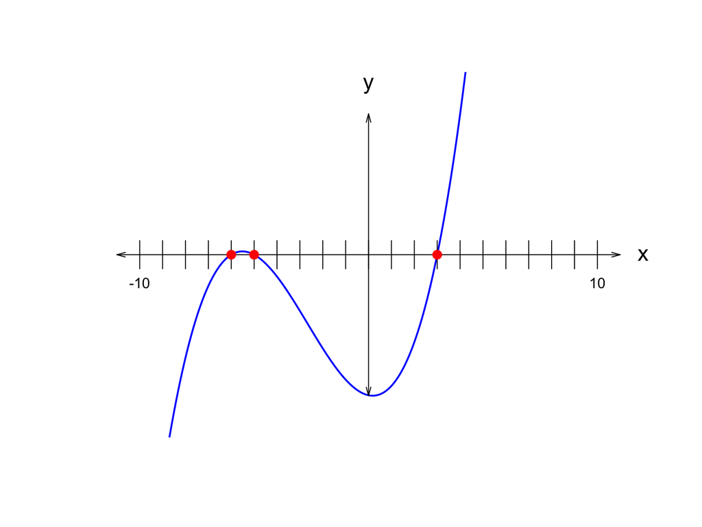

Find $B$, $C$, and $D$.

- $B=$ ##ANSWER1##
- $C=$ ##ANSWER2##
- $D=$ ##ANSWER3##

## Answerlist

- -18
- -17
- -16
- -15
- -14
- -13
- -12
- -11
- -10
- -9
- -8
- -7
- -6
- -5
- -4
- -3
- -2
- -1
- 0
- 1
- 2
- 3
- 4
- 5
- 6
- 7
- 8
- 9
- 10
- 11
- 12
- 13
- 14
- 15
- 16
- 17
- 18
- -36
- -35
- -34
- -33
- -32
- -31
- -30
- -29
- -28
- -27
- -26
- -25
- -24
- -23
- -22
- -21
- -20
- -19
- -18
- -17
- -16
- -15
- -14
- -13
- -12
- -11
- -10
- -9
- -8
- -7
- -6
- -5
- -4
- -3
- -2
- -1
- 0
- 1
- 2
- 3
- 4
- 5
- 7
- 8
- 9
- 11
- 12
- 13
- 14
- 15
- 16
- 17
- 19
- 20
- 21
- 23
- 24
- 26
- 27
- 28
- 29
- 31
- 32
- 33
- 34
- 35
- 36
- 38
- 39
- 40
- 41
- 44
- 45
- 47
- 48
- 52
- 54
- 55
- 56
- 60
- 63
- 64
- 65
- 72
- 74
- 75
- 84
- 85
- 96
- 108
- -216
- -180
- -150
- -144
- -125
- -120
- -108
- -100
- -96
- -90
- -80
- -75
- -72
- -64
- -60
- -54
- -50
- -48
- -45
- -40
- -36
- -32
- -30
- -27
- -25
- -24
- -20
- -18
- -16
- -15
- -12
- -10
- -9
- -8
- -6
- -5
- -4
- -3
- -2
- -1
- 1
- 2
- 3
- 4
- 5
- 6
- 8
- 9
- 10
- 12
- 15
- 16
- 18
- 20
- 24
- 25
- 27
- 30
- 32
- 36
- 40
- 45
- 48
- 50
- 54
- 60
- 64
- 72
- 75
- 80
- 90
- 96
- 100
- 108
- 120
- 125
- 144
- 150
- 180
- 216

# Solution

First, write the cubic polynomial in factored form (based on the three roots).

$$f(x)~=~(x+{6})(x+{5})(x-{3})$$

Partially expand the expression by writing $(x+{6})(x+{5})$ in standard form. To do this, we can use the FOIL method or a box.

| * | $x$ | $6$ |
| --- | --- | --- |
| $x$ | $x^2$ | $6x$ |
| $5$ | $5x$ | $30$ |

$$f(x)~=~
\left(x^{2}+{5}x+{6}x+{30}\right)(x-{3})$$

Combine like terms.

$$f(x)~=~
\left(x^{2}+{11}x+{30}\right)(x-{3})$$

Now, multiply the quadratic by the linear.

| * | $x^2$ | $11x$ | $30$ |
| --- | --- | --- | --- |
| $x$ | $x^3$ | $11x^2$ | $30x$ |
| $-3$ | $-3x^2$ | $-33x$ | $-90$ |

$$f(x)~=~x^{3}-{3}x^{2}+{11}x^{2}-{33}x+{30}x-{90}$$

Combine like terms.

$$f(x)~=~x^{3}+{8}x^{2}-{3}x-{90}$$

Thus,

- $B=8$
- $C=-3$
- $D=-90$

# Meta-information

extype: cloze exclozetype: schoice|schoice|schoice exsolution: 0000000000000000000000000010000000000|000000000000000000000000000000000100000000000000000000000000000000000000000000000000000000|00000000010000000000000000000000000000000000000000000000000000000000000000000000 exname: cubic_from_zeros